# DESeq2 <-> eyeIntegration <-> outside data differential expression tutorial

Prashit Parikh and David McGaughey

2023-04-20

# 1. Overview

This guide will illustrate how you can perform differential gene expression analysis by integrating your locally processed data with RNA-seq data from the recount3 project and our Eye in a Disk (EiaD) database. For a full explanation of the recount3 package, please visit the [recount3 quick start guide here](https://bioconductor.org/packages/3.17/bioc/vignettes/recount3/inst/doc/recount3-quickstart.html#21_Installing_recount3).

We will begin by downloading and loading necessary packages for use throughout this tutorial:

Comment out the `install.packages` or `BiocManager::install` if necessary (you get errors on `library` loads)

```r
# # Install BiocManager for package installation assistance if it is not already available in the current R session
# if (!requireNamespace("BiocManager", quietly = TRUE)) {install.packages("BiocManager")}
#
# # The following packages will be used throughout this tutorial for data manipulation
# install.packages("tidyverse")
# install.packages("tibble")
# install.packages("data.table")
# Load packages
library(tidyverse)
library(tibble)
library(data.table)
```

# 2. Installation and Data Download

recount3 data can be obtained from the recount3 package in R, which you can download following these steps in your R session:

```r
# # Install recount3
# BiocManager::install("recount3")
```

For EiaD data, we need to download the EiaD_library, which is a recount3 library mirror containing all samples from the eyeIntegration web application, to our local machine. [The data library can be found here](https://hpc.nih.gov/~parikhpp/EiaD/EiaD_library.tar.gz). Following download, you must unzip the data directory prior to use with recount3 compatible functions. **This file is currently about 6GB in size.**

```r
# example - it may be easier to use a internet browser as that will give more info on progress / download speed
#options(timeout = max(10000, getOption("timeout")))
#download.file('https://hpc.nih.gov/~parikhpp/EiaD/EiaD_library.tar.gz', '~/Downloads/EiaD_library.tar.gz', quiet = FALSE)

# this will extract the folder in your current working directory
#system('tar -xzvf ~/Downloads/EiaD_library.tar.gz')
```

# 3. Quick Start

Now that both the recount3 and EiaD data has been downloaded, we can prepare for differential gene expression: analysis:

## 3.1.A Explore EiaD Metadata

Some pointers:

- the data_location column has three types: recount3, recount3-GTEX, or local
  - the first two means the data can be pulled from recount3 directly
  - local means you have to pull it from the `EiaD_library.tar.gz` you downloaded and extracted above
- The core metadata fields are `Cohort` (eye or body), `Tissue` (e.g. RPE, Retina, Cornea), `Source` (e.g. tissue, primary culture), and `Age` (e.g. fetal, adult)

```r
# Import the metadata
EiaD_meta <- fread("https://hpc.nih.gov/~parikhpp/EiaD/eyeIntegration22_meta_2023_03_03.csv.gz")
```

[output not shown]

```r
EiaD_meta %>% sample_n(10)
```

| sample_accession | study_accession | Cohort | Tissue | Source | Age | region | Sub_Tissue | study_title | study_abstract | sample_title | sample_attribute | BioSample | run_accession | Source_details | data_location | Library_Notes | Comment | Origin | Age_Days | Sample_comment | geo | gtex_accession | gtex_sra_run_accession | Perturbation |
| --- | --- | --- | --- | --- | --- | --- | --- | --- | --- | --- | --- | --- | --- | --- | --- | --- | --- | --- | --- | --- | --- | --- | --- | --- |
| SRS631296 | SRP012682 | Body | Brain | Native | Adult | NA | Nucleus accumbens (basal ganglia) | Genotype-Tissue Expression (GTEx) Common Fund Project | Lay Description. The aim of the Genotype-Tissue Expression (GTEx) Project is to increase our understanding of how changes in our genes affect human health and disease with the ultimate goal of improvi… | RNA-Seq of homo sapiens: adult male Brain - Nucleus accumbens (basal ganglia): Sample GTEX-13FHP-0011-R6b-SM-5LZY6; Non-tumor RNA:Total RNA sample from Brain - Nucleus accumbens (basal ganglia) of a h… | phs000424 | SAMN02791996 | GTEX.13FHP.0011.R6b.SM.5LZY6.1 | NA | recount3-GTEX | NA | NA | Adult Tissue | . | Brain - Nucleus accumbens (basal ganglia) | NA | GTEX-13FHP-0011-R6b-SM-5LZY6 | SRR8220695 | NA |
| SRS526671 | SRP012682 | Body | Stomach | Native | Adult | NA | NA | Genotype-Tissue Expression (GTEx) Common Fund Project | Lay Description. The aim of the Genotype-Tissue Expression (GTEx) Project is to increase our understanding of how changes in our genes affect human health and disease with the ultimate goal of improvi… | RNA-Seq of homo sapiens: adult female Stomach: Sample GTEX-RTLS-2626-SM-46MUJ; Non-tumor RNA:Total RNA sample from Stomach of a human female participant in the dbGaP study """"""""""""""""""""""""""""… | phs000424 | SAMN02464829 | GTEX.RTLS.2626.SM.46MUJ.1 | NA | recount3-GTEX | NA | NA | Adult Tissue | . | Stomach | NA | GTEX-RTLS-2626-SM-46MUJ | SRR1101981 | NA |
| SRS526662 | SRP012682 | Body | Spleen | Native | Adult | NA | NA | Genotype-Tissue Expression (GTEx) Common Fund Project | Lay Description. The aim of the Genotype-Tissue Expression (GTEx) Project is to increase our understanding of how changes in our genes affect human health and disease with the ultimate goal of improvi… | RNA-Seq of homo sapiens: adult male Spleen: Sample GTEX-RUSQ-0126-SM-47JWV; Non-tumor RNA:Total RNA sample from Spleen of a human male participant in the dbGaP study """"""""""""""""""""""""""""""""""… | phs000424 | SAMN02465063 | GTEX.RUSQ.0126.SM.47JWV.1 | NA | recount3-GTEX | NA | NA | Adult Tissue | . | Spleen | NA | GTEX-RUSQ-0126-SM-47JWV | SRR1101765 | NA |
| SRS636112 | SRP012682 | Body | Esophagus | Native | Adult | NA | Gastroesophageal Junction | Genotype-Tissue Expression (GTEx) Common Fund Project | Lay Description. The aim of the Genotype-Tissue Expression (GTEx) Project is to increase our understanding of how changes in our genes affect human health and disease with the ultimate goal of improvi… | RNA-Seq of homo sapiens: adult female Esophagus - Gastroesophageal Junction: Sample GTEX-ZF2S-1326-SM-4WWAZ; Non-tumor RNA:Total RNA sample from Esophagus - Gastroesophageal Junction of a human female… | phs000424 | SAMN02792845 | GTEX.ZF2S.1326.SM.4WWAZ.1 | NA | recount3-GTEX | NA | NA | Adult Tissue | . | Esophagus - Gastroesophageal Junction | NA | GTEX-ZF2S-1326-SM-4WWAZ | SRR1387899 | NA |
| SRS2582153 | SRP119766 | Eye | Retina | Native | Fetal | NA | NA | Molecular anatomy of the developing human retina | Clinical and genetic heterogeneity associated with retinal diseases makes stem cell-based therapies an attractive strategy for personalized medicine. However, we have limited understanding of the timi… | GSM2808446: D105; Homo sapiens; RNA-Seq; D105 | Retina | SAMN07774581 | SRR6158810 | NA | recount3 | NA | NA | Fetal Tissue | 105 | Retina - Fetal Tissue | NA | NA | NA | NA |
| SRS634799 | SRP012682 | Body | Liver | Native | Adult | NA | NA | Genotype-Tissue Expression (GTEx) Common Fund Project | Lay Description. The aim of the Genotype-Tissue Expression (GTEx) Project is to increase our understanding of how changes in our genes affect human health and disease with the ultimate goal of improvi… | GTEx Illumina RNA sequencing of transcriptome paired-end library 'Solexa-215712' containing sample 'GTEX-ZYT6-0626-SM-5E45V' from subject 'GTEX-ZYT6'; Non-tumor RNA:Total RNA sample from Liver of a hu… | phs000424 | SAMN02791975 | GTEX.ZYT6.0626.SM.5E45V.1 | NA | recount3-GTEX | NA | NA | Adult Tissue | . | Liver | NA | GTEX-ZYT6-0626-SM-5E45V | SRR8232825 | NA |
| SRS524836 | SRP012682 | Body | Adipose Tissue | Native | Adult | NA | Subcutaneous | Genotype-Tissue Expression (GTEx) Common Fund Project | Lay Description. The aim of the Genotype-Tissue Expression (GTEx) Project is to increase our understanding of how changes in our genes affect human health and disease with the ultimate goal of improvi… | GTEx Illumina RNA sequencing of transcriptome paired-end library 'Solexa-165060' containing sample 'GTEX-TKQ1-1126-SM-4GIAZ' from subject 'GTEX-TKQ1'; Non-tumor RNA:Total RNA sample from Adipose - Sub… | phs000424 | SAMN02465724 | GTEX.TKQ1.1126.SM.4GIAZ.1 | NA | recount3-GTEX | NA | NA | Adult Tissue | . | Adipose - Subcutaneous | NA | GTEX-TKQ1-1126-SM-4GIAZ | SRR1083311 | NA |
| SRS3493148 | SRP151763 | Eye | Retina | Native | Adult | NA | NA | Integrated analysis of genetic variants regulating retinal transcriptome (GREx) identifies genes underlying age-related macular degeneration | Age-related macular degeneration (AMD) is a complex multifactorial disease with at least 34 loci contributing to genetic susceptibility. To gain functional understanding of AMD genetics, we generated … | GSM3191267: R42015-398pf_379-IR_L6; Homo sapiens; RNA-Seq; R42015-398pf_379-IR_L6 | Retina | SAMN09427761 | SRR7461130 | Adult Tissue MGS 1 | recount3 | NA | NA | Adult Tissue | . | Retina - Adult Tissue MGS 1 | NA | NA | NA | Adult Tissue MGS 1 |
| SRS639242 | SRP012682 | Body | Brain | Native | Adult | NA | Nucleus accumbens (basal ganglia) | Genotype-Tissue Expression (GTEx) Common Fund Project | Lay Description. The aim of the Genotype-Tissue Expression (GTEx) Project is to increase our understanding of how changes in our genes affect human health and disease with the ultimate goal of improvi… | GTEx Illumina RNA sequencing of transcriptome paired-end library 'Solexa-216135' containing sample 'GTEX-12ZZY-0011-R6b-SM-5EGLA' from subject 'GTEX-12ZZY'; Non-tumor RNA:Total RNA sample from Brain -… | phs000424 | SAMN02788180 | GTEX.12ZZY.0011.R6b.SM.5EGLA.1 | NA | recount3-GTEX | NA | NA | Adult Tissue | . | Brain - Nucleus accumbens (basal ganglia) | NA | GTEX-12ZZY-0011-R6b-SM-5EGLA | SRR1414833 | NA |
| SRS3492913 | SRP151763 | Eye | Retina | Native | Adult | NA | NA | Integrated analysis of genetic variants regulating retinal transcriptome (GREx) identifies genes underlying age-related macular degeneration | Age-related macular degeneration (AMD) is a complex multifactorial disease with at least 34 loci contributing to genetic susceptibility. To gain functional understanding of AMD genetics, we generated … | GSM3191030: R42016-180pf_162-IR_L8; Homo sapiens; RNA-Seq; R42016-180pf_162-IR_L8 | Retina | SAMN09428077 | SRR7460893 | Adult Tissue MGS 1 | recount3 | NA | NA | Adult Tissue | . | Retina - Adult Tissue MGS 1 | NA | NA | NA | Adult Tissue MGS 1 |

```r
EiaD_meta %>% filter(Tissue == 'Retina', Source == 'Native', Age == 'Adult')
```

| sample_accession | study_accession | Cohort | Tissue | Source | Age | region | Sub_Tissue | study_title | study_abstract | sample_title | sample_attribute | BioSample | run_accession | Source_details | data_location | Library_Notes | Comment | Origin | Age_Days | Sample_comment | geo | gtex_accession | gtex_sra_run_accession | Perturbation |
| --- | --- | --- | --- | --- | --- | --- | --- | --- | --- | --- | --- | --- | --- | --- | --- | --- | --- | --- | --- | --- | --- | --- | --- | --- |
| ERS5672529 | ERP126780 | Eye | Retina | Native | Adult | NA | NA | RNAseq 50 Normal Human Retina | RNA-seq of post-mort retina donor without clinically relevant visual impairment. Ploy-A enriched. 75-nt paired-end. Short time lapse between tissue sampling and cDNA generation. | Illumina HiSeq 1000 paired end sequencing; RNAseq 50 Normal Human Retina; Sample 1 | 2/4/21 | SAMEA7985247 | ERR5236614 | NA | local | NA | NA | Adult Tissue | . | Retina - Adult Tissue | NA | NA | NA | NA |
| ERS5672530 | ERP126780 | Eye | Retina | Native | Adult | NA | NA | RNAseq 50 Normal Human Retina | RNA-seq of post-mort retina donor without clinically relevant visual impairment. Ploy-A enriched. 75-nt paired-end. Short time lapse between tissue sampling and cDNA generation. | Illumina HiSeq 1000 paired end sequencing; RNAseq 50 Normal Human Retina; Sample 10 | 2/4/21 | SAMEA7985248 | ERR5236615 | NA | local | NA | NA | Adult Tissue | . | Retina - Adult Tissue | NA | NA | NA | NA |
| ERS5672531 | ERP126780 | Eye | Retina | Native | Adult | NA | NA | RNAseq 50 Normal Human Retina | RNA-seq of post-mort retina donor without clinically relevant visual impairment. Ploy-A enriched. 75-nt paired-end. Short time lapse between tissue sampling and cDNA generation. | Illumina HiSeq 1000 paired end sequencing; RNAseq 50 Normal Human Retina; Sample 11 | 2/4/21 | SAMEA7985249 | ERR5236616 | NA | local | NA | NA | Adult Tissue | . | Retina - Adult Tissue | NA | NA | NA | NA |
| ERS5672532 | ERP126780 | Eye | Retina | Native | Adult | NA | NA | RNAseq 50 Normal Human Retina | RNA-seq of post-mort retina donor without clinically relevant visual impairment. Ploy-A enriched. 75-nt paired-end. Short time lapse between tissue sampling and cDNA generation. | Illumina HiSeq 1000 paired end sequencing; RNAseq 50 Normal Human Retina; Sample 12 | 2/4/21 | SAMEA7985250 | ERR5236617 | NA | local | NA | NA | Adult Tissue | . | Retina - Adult Tissue | NA | NA | NA | NA |
| ERS5672533 | ERP126780 | Eye | Retina | Native | Adult | NA | NA | RNAseq 50 Normal Human Retina | RNA-seq of post-mort retina donor without clinically relevant visual impairment. Ploy-A enriched. 75-nt paired-end. Short time lapse between tissue sampling and cDNA generation. | Illumina HiSeq 1000 paired end sequencing; RNAseq 50 Normal Human Retina; Sample 13 | 2/4/21 | SAMEA7985251 | ERR5236618 | NA | local | NA | NA | Adult Tissue | . | Retina - Adult Tissue | NA | NA | NA | NA |
| ERS5672534 | ERP126780 | Eye | Retina | Native | Adult | NA | NA | RNAseq 50 Normal Human Retina | RNA-seq of post-mort retina donor without clinically relevant visual impairment. Ploy-A enriched. 75-nt paired-end. Short time lapse between tissue sampling and cDNA generation. | Illumina HiSeq 1000 paired end sequencing; RNAseq 50 Normal Human Retina; Sample 14 | 2/4/21 | SAMEA7985252 | ERR5236619 | NA | local | NA | NA | Adult Tissue | . | Retina - Adult Tissue | NA | NA | NA | NA |
| ERS5672535 | ERP126780 | Eye | Retina | Native | Adult | NA | NA | RNAseq 50 Normal Human Retina | RNA-seq of post-mort retina donor without clinically relevant visual impairment. Ploy-A enriched. 75-nt paired-end. Short time lapse between tissue sampling and cDNA generation. | Illumina HiSeq 1000 paired end sequencing; RNAseq 50 Normal Human Retina; Sample 15 | 2/4/21 | SAMEA7985253 | ERR5236620 | NA | local | NA | NA | Adult Tissue | . | Retina - Adult Tissue | NA | NA | NA | NA |
| ERS5672536 | ERP126780 | Eye | Retina | Native | Adult | NA | NA | RNAseq 50 Normal Human Retina | RNA-seq of post-mort retina donor without clinically relevant visual impairment. Ploy-A enriched. 75-nt paired-end. Short time lapse between tissue sampling and cDNA generation. | Illumina HiSeq 1000 paired end sequencing; RNAseq 50 Normal Human Retina; Sample 16 | 2/4/21 | SAMEA7985254 | ERR5236621 | NA | local | NA | NA | Adult Tissue | . | Retina - Adult Tissue | NA | NA | NA | NA |
| ERS5672537 | ERP126780 | Eye | Retina | Native | Adult | NA | NA | RNAseq 50 Normal Human Retina | RNA-seq of post-mort retina donor without clinically relevant visual impairment. Ploy-A enriched. 75-nt paired-end. Short time lapse between tissue sampling and cDNA generation. | Illumina HiSeq 1000 paired end sequencing; RNAseq 50 Normal Human Retina; Sample 17 | 2/4/21 | SAMEA7985255 | ERR5236622 | NA | local | NA | NA | Adult Tissue | . | Retina - Adult Tissue | NA | NA | NA | NA |
| ERS5672538 | ERP126780 | Eye | Retina | Native | Adult | NA | NA | RNAseq 50 Normal Human Retina | RNA-seq of post-mort retina donor without clinically relevant visual impairment. Ploy-A enriched. 75-nt paired-end. Short time lapse between tissue sampling and cDNA generation. | Illumina HiSeq 1000 paired end sequencing; RNAseq 50 Normal Human Retina; Sample 18 | 2/4/21 | SAMEA7985256 | ERR5236623 | NA | local | NA | NA | Adult Tissue | . | Retina - Adult Tissue | NA | NA | NA | NA |

[output cut: 584 more lines]

```r
ERP126780_retina_runs <- EiaD_meta %>% filter(Tissue == 'Retina', Source == 'Native', Age == 'Adult') %>%
  filter(study_accession == 'ERP126780') %>%
  pull(run_accession)
```

For this contrived example I filter to only show RPE tissue from adult primary culture that is in recount3. SRP186009 meets this criteria. Again I capture the exact files to ensure I don’t get any hitchhikers with my analysis.

```r
EiaD_meta %>% filter(Tissue == 'RPE', Source == 'Primary culture', Age == 'Adult') %>% filter(data_location == 'recount3')
```

| sample_accession | study_accession | Cohort | Tissue | Source | Age | region | Sub_Tissue | study_title | study_abstract | sample_title | sample_attribute | BioSample | run_accession | Source_details | data_location | Library_Notes | Comment | Origin | Age_Days | Sample_comment | geo | gtex_accession | gtex_sra_run_accession | Perturbation |
| --- | --- | --- | --- | --- | --- | --- | --- | --- | --- | --- | --- | --- | --- | --- | --- | --- | --- | --- | --- | --- | --- | --- | --- | --- |
| SRS4372080 | SRP186009 | Eye | RPE | Primary culture | Adult | NA | NA | RNA-sequencing uncovers transcriptomes of human diseased, healthy, and disease-modeled retinal pigment epithelial cells. | Human donor derived retinal pigment epithelial cells from healthy, diseased, and disease-modeled sources underwent RNA-sequencing to identify unique, gene signatures. Overall design: Retinal pigment e… | GSM3610125: RPE_15_S7; Homo sapiens; RNA-Seq; RPE_15_S7 | Retinal | SAMN10953779 | SRR8582344 | NA | recount3 | NA | NA | NA | NA | NA | NA | NA | NA | NA |
| SRS4372081 | SRP186009 | Eye | RPE | Primary culture | Adult | NA | NA | RNA-sequencing uncovers transcriptomes of human diseased, healthy, and disease-modeled retinal pigment epithelial cells. | Human donor derived retinal pigment epithelial cells from healthy, diseased, and disease-modeled sources underwent RNA-sequencing to identify unique, gene signatures. Overall design: Retinal pigment e… | GSM3610126: RPE_18_S12; Homo sapiens; RNA-Seq; RPE_18_S12 | Retinal | SAMN10953778 | SRR8582345 | NA | recount3 | NA | NA | NA | NA | NA | NA | NA | NA | NA |
| SRS4372082 | SRP186009 | Eye | RPE | Primary culture | Adult | NA | NA | RNA-sequencing uncovers transcriptomes of human diseased, healthy, and disease-modeled retinal pigment epithelial cells. | Human donor derived retinal pigment epithelial cells from healthy, diseased, and disease-modeled sources underwent RNA-sequencing to identify unique, gene signatures. Overall design: Retinal pigment e… | GSM3610127: RPE_37_S8; Homo sapiens; RNA-Seq; RPE_37_S8 | Retinal | SAMN10953777 | SRR8582346 | NA | recount3 | NA | NA | NA | NA | NA | NA | NA | NA | NA |

```r
SRP186009_rpe_runs <- EiaD_meta %>% filter(Tissue == 'RPE', Source == 'Primary culture', Age == 'Adult') %>% filter(data_location == 'recount3') %>%
  pull(run_accession)
```

## 3.1.A. Creating a RangedSummarizedExperiment (rse) Object for recount3 data

Loading the recount3 package will load necessary dependencies and functions required for use in preparing our data for downstream analysis. We will begin by creating an rse object, which enables access to the gene level expression data from recount3.

```r
# Load the recount3 package
library(recount3)

# Find all available human projects in the recount3 database
human_projects <- available_projects()
```

```
2023-04-20 15:00:22 caching file sra.recount_project.MD.gz.
2023-04-20 15:00:23 caching file gtex.recount_project.MD.gz.
2023-04-20 15:00:24 caching file tcga.recount_project.MD.gz.
```

```r
# Locate your project of interest. Here we use SRP186009 as an example.
proj_info_SRP186009 <- subset(human_projects,
                    project == "SRP186009" & project_type == "data_sources")

# Create rse object using the gencode v29 annotation
rse_gene_SRP186009 <- create_rse(proj_info_SRP186009, annotation = "gencode_v29")
```

```
2023-04-20 15:00:25 downloading and reading the metadata.
2023-04-20 15:00:27 caching file sra.sra.SRP186009.MD.gz.
2023-04-20 15:00:27 caching file sra.recount_project.SRP186009.MD.gz.
2023-04-20 15:00:28 caching file sra.recount_qc.SRP186009.MD.gz.
2023-04-20 15:00:29 caching file sra.recount_seq_qc.SRP186009.MD.gz.
2023-04-20 15:00:30 caching file sra.recount_pred.SRP186009.MD.gz.
2023-04-20 15:00:30 downloading and reading the feature information.
2023-04-20 15:00:31 caching file human.gene_sums.G029.gtf.gz.
2023-04-20 15:00:32 downloading and reading the counts: 8 samples across 64837 features.
2023-04-20 15:00:32 caching file sra.gene_sums.SRP186009.G029.gz.
2023-04-20 15:00:33 constructing the RangedSummarizedExperiment (rse) object.
```

```r
# IMPORTANT
# HERE WE ENSURE WE ONLY USE THE SPECIFIC SAMPLES WE WANT
# SOME STUDIES HAVE MULTIPLE TYPES OF SAMPLES!!!!!
# IN THIS EXAMPLE THE FULL STUDY HAS 8 BUT WE ONLY USE 3!!!!!
rse_gene_SRP186009[, SRP186009_rpe_runs]
```

```
class: RangedSummarizedExperiment
dim: 64837 3
metadata(8): time_created recount3_version ... annotation recount3_url
assays(1): raw_counts
rownames(64837): ENSG00000278704.1 ENSG00000277400.1 ... ENSG00000182484.15_PAR_Y ENSG00000227159.8_PAR_Y
rowData names(10): source type ... havana_gene tag
colnames(3): SRR8582344 SRR8582345 SRR8582346
colData names(175): rail_id external_id ... recount_pred.curated.cell_line BigWigURL
```

```r
rse_gene_SRP186009 <- rse_gene_SRP186009[, SRP186009_rpe_runs]
```

This process can be repeated for each study you would like to pull from recount3

## 3.1.B. Creating a RangedSummarizedExperiment (rse) Object for EiaD data

This time we will utilize the same create_rse_manual function using the EiaD library mirror for recount3. This pulls that retina set we found earlier.

```r
# Locate your project of interest. Here we use ERP126780 as an example that we identified above as adult retina tissue.
rse_gene_ERP126780 <- create_rse_manual("ERP126780", recount3_url = "EiaD_library/", annotation = "gencode_v29")
```

```
2023-04-20 15:00:34 downloading and reading the metadata.
Warning: The 'url' <EiaD_library//human/data_sources/EiaD/metadata/80/ERP126780/EiaD.recount_seq_qc.ERP126780.MD.gz> does not exist or is not available.Warning: The 'url' <EiaD_library//human/data_sources/EiaD/metadata/80/ERP126780/EiaD.recount_pred.ERP126780.MD.gz> does not exist or is not availabl…
2023-04-20 15:00:34 downloading and reading the counts: 50 samples across 64837 features.
2023-04-20 15:00:34 constructing the RangedSummarizedExperiment (rse) object.
```

```r
# technically not necessary here as this study is entirely the same kind of sample, but good practice nonetheless
rse_gene_ERP126780 <- rse_gene_ERP126780[,ERP126780_retina_runs]
```

More information about how to structure a recount3 library mirror can be found [here](https://www.bioconductor.org/packages/devel/bioc/vignettes/recount3/inst/doc/recount3-quickstart.html#413_Your_own_mirror).

Now that we have learned how to successfully create rse objects, we can prepare our data for differential gene expression analysis.

# 4. Transforming and Combining Our Data to Obtain Raw Gene Counts for Use in DESeq2 Analysis

Using our rse objects, we can obtain gene count data to be used directly in differential gene expression analysis. This process will be the same for EiaD, recount3, and locally processed samples which were produced using the [Monorail RNA-Seq Processing Pipeline](https://github.com/langmead-lab/monorail-external).

```r
# Compute raw counts from rse and save them as a new attribute in the rse object

# recount3 rse object
assays(rse_gene_SRP186009)$raw_counts <- compute_read_counts(rse_gene_SRP186009)
# EiaD rse object
assays(rse_gene_ERP126780)$raw_counts <- compute_read_counts(rse_gene_ERP126780)

# Combine all counts from rse objects
DESeq_counts <- bind_cols(assays(rse_gene_SRP186009)$raw_counts, assays(rse_gene_ERP126780)$raw_counts)
# Transform counts into matrix for use in differential expression analysis
DESeq_counts <- DESeq_counts %>% as.matrix()
# get gene names back in
row.names(DESeq_counts) <- row.names(assays(rse_gene_SRP186009)$raw_counts)
```

# 5. Build the metadata object

## 5.1.A. Importing Metadata for our previously identified samples

```r
# Subset the full metadata to match the identified samples
DESeq_meta <- EiaD_meta %>% filter(run_accession %in% c(SRP186009_rpe_runs, ERP126780_retina_runs))
```

## Sidebar: Finding Metadata for recount3 Exclusive Samples (not contained in EiaD) and Binding Them to Our Metadata for DESeq2 Analysis

While the samples we used are in EiaD, you can use any data in recount3 using similar principles.

recount3 metadata is stored in the recount3 package, and can be extracted using the colData function from the recount3 package in R.

You can search recount3 studies [here](https://jhubiostatistics.shinyapps.io/recount3-study-explorer/) on the web to quickly identify desired samples.

We will use SRP096788, which we found by searching for “iPSC neuron” and flipping the sample count to the lowest in the recount3 web table, for this example:

```r
# Locate your project of interest
rse_gene_SRP096788 <- subset(human_projects,
                    project == "SRP096788" & project_type == "data_sources")

# Create rse object using the gencode v29 annotation
rse_gene_SRP096788 <- create_rse(rse_gene_SRP096788, annotation = "gencode_v29")
```

```
2023-04-20 15:00:35 downloading and reading the metadata.
2023-04-20 15:00:36 caching file sra.sra.SRP096788.MD.gz.
2023-04-20 15:00:37 caching file sra.recount_project.SRP096788.MD.gz.
2023-04-20 15:00:39 caching file sra.recount_qc.SRP096788.MD.gz.
2023-04-20 15:00:40 caching file sra.recount_seq_qc.SRP096788.MD.gz.
2023-04-20 15:00:41 caching file sra.recount_pred.SRP096788.MD.gz.
2023-04-20 15:00:41 downloading and reading the feature information.
2023-04-20 15:00:44 caching file human.gene_sums.G029.gtf.gz.
2023-04-20 15:00:44 downloading and reading the counts: 3 samples across 64837 features.
2023-04-20 15:00:45 caching file sra.gene_sums.SRP096788.G029.gz.
2023-04-20 15:00:45 constructing the RangedSummarizedExperiment (rse) object.
```

```r
# Extracting metadata from our rse object
# Converting it to a dataframe
# Selecting to keep only those variables which align with the EiaD metadata
# Altering column names to assist in later joining with the EiaD metadata
SRP096788_meta <- colData(rse_gene_SRP096788) %>% as_tibble() %>%
  dplyr::select(external_id, sra.sample_acc.x, study) %>% setnames(c("run_accession", "sample_accession", "study_accession")) %>%
  mutate(Source = 'iPSC', Tissue = 'Neuron')
```

## 5.2 Ensuring Row Names for Metadata and Column Names for Gene Counts are in Alignment

DESeq2 assumes the columns of our input gene counts matrix to match the row names of our metadata. The following command ensures that this order is followed.

```r
DESeq_counts <- DESeq_counts[,DESeq_meta$run_accession]
```

# 6. Run DESeq2 for differential testing

We will begin by downloading the DESeq2 R package and loading it into our current session.

```r
# # Install DESeq2
# BiocManager::install("DESeq2")
# Load DESeq2
library(DESeq2)
```

Now we can utilize our prepared gene counts data and metadata to perform differential expression analysis:

More information about DESeq2 can be found [here](https://bioconductor.org/packages/release/bioc/html/DESeq2.html).

```r
# Prepare data for DESeq analysis
dds <- DESeqDataSetFromMatrix(countData = DESeq_counts,
                              colData = DESeq_meta,
                              design = ~ Tissue)
```

```
Warning: some variables in design formula are characters, converting to factors
```

```r
# Run DESeq
DESeq2Table <- DESeq(dds)
```

```
-- replacing outliers and refitting for 426 genes
-- DESeq argument 'minReplicatesForReplace' = 7
-- original counts are preserved in counts(dds)
```

## Top 100 differentially expressed genes

Note how the genes are in the Ensembl format (default for recount3)

```r
top100 <- results(DESeq2Table) %>% as_tibble(rownames = 'ensembl_gene_id') %>% arrange(padj) %>% head(100)
top100
```

| ensembl_gene_id | baseMean | log2FoldChange | lfcSE | stat | pvalue | padj |
| --- | --- | --- | --- | --- | --- | --- |
| ENSG00000253309.6 | 5405.86619 | 11.077068 | 0.26216980 | 42.25150 | 0.000000e+00 | 0.000000e+00 |
| ENSG00000146411.5 | 2110.93791 | 7.930780 | 0.20435587 | 38.80867 | 0.000000e+00 | 0.000000e+00 |
| ENSG00000250644.3 | 14288.92469 | 5.533040 | 0.15003143 | 36.87921 | 9.955948e-298 | 1.198099e-293 |
| ENSG00000164175.14 | 365.80899 | 7.983578 | 0.24415369 | 32.69899 | 1.614503e-234 | 1.457169e-230 |
| ENSG00000196123.12 | 6806.35439 | -4.381876 | 0.13487792 | -32.48772 | 1.589817e-231 | 1.147912e-227 |
| ENSG00000102572.14 | 4122.29531 | 4.517440 | 0.13956448 | 32.36812 | 7.713418e-230 | 4.641164e-226 |
| ENSG00000118322.13 | 201.58703 | 11.521887 | 0.35850915 | 32.13834 | 1.285471e-226 | 6.629723e-223 |
| ENSG00000115556.13 | 14295.85997 | -8.390012 | 0.26175592 | -32.05281 | 2.006300e-225 | 9.053932e-222 |
| ENSG00000132639.12 | 17897.49227 | -9.356237 | 0.29462878 | -31.75602 | 2.622450e-221 | 1.051952e-217 |
| ENSG00000169439.11 | 1469.92350 | 4.650013 | 0.14739645 | 31.54766 | 1.930587e-218 | 6.969804e-215 |

[output cut: 90 more lines]

### Now human readable

We see how some of the top positive log2FoldChange genes (SERPINE3, PMEL) and negative (RHO, PDE6A) are associated with RPE and Retina, respectively.

You can click on the column fields to sort by that column.

```r
#BiocManager::install('biomaRt')
library(biomaRt)
mart <- useEnsembl("ensembl", "hsapiens_gene_ensembl")
conversion_table <- getBM(c("ensembl_gene_id","hgnc_symbol","description"), mart = mart)
top100 %>%
  # ugly code to remove the .digit ending to get aligment of ethe ensembl id
  mutate(ensembl_gene_id = gsub('\\.\\d+','',ensembl_gene_id)) %>%
  left_join(conversion_table) %>%
  relocate(hgnc_symbol) %>%
  arrange(-log2FoldChange) %>%
  DT::datatable()
```

|  | hgnc_symbol | ensembl_gene_id | baseMean | log2FoldChange | lfcSE | stat | pvalue | padj | description |
| --- | --- | --- | --- | --- | --- | --- | --- | --- | --- |
| 1 | ATP10B | ENSG00000118322 | 201.58702796325 | 11.5218874327482 | 0.358509154535079 | 32.1383353451322 | 1.2854706032179e-226 | 6.6297228167675e-223 | ATPase phospholipid transporting 10B (putative) [Source:HGNC Symbol;Acc:HGNC:13543] |
| 2 | PMEL | ENSG00000185664 | 4307.57892186736 | 11.4538901196016 | 0.412531383683234 | 27.7648939514297 | 1.15183446481419e-169 | 2.31019599159565e-166 | premelanosome protein [Source:HGNC Symbol;Acc:HGNC:10880] |
| 3 | SLC6A20 | ENSG00000163817 | 1670.95414349548 | 11.2899289222737 | 0.47801199798259 | 23.6185053302468 | 2.48795939501274e-123 | 1.4257192075992e-120 | solute carrier family 6 member 20 [Source:HGNC Symbol;Acc:HGNC:30927] |
| 4 | SERPINE3 | ENSG00000253309 | 5405.86618914452 | 11.0770684080421 | 0.262169804449347 | 42.2515034914414 | 0 | 0 | serpin family E member 3 [Source:HGNC Symbol;Acc:HGNC:24774] |
| 5 |  | ENSG00000279017 | 48.0925124997384 | 11.037188518569 | 0.483203886619631 | 22.8416799289061 | 1.76796446249779e-115 | 8.51027373667938e-113 | TEC |
| 6 | IL13RA2 | ENSG00000123496 | 104.113357336424 | 10.7602360524905 | 0.413637058869069 | 26.0137137661462 | 3.46474621535286e-149 | 3.57383622476197e-146 | interleukin 13 receptor subunit alpha 2 [Source:HGNC Symbol;Acc:HGNC:5975] |
| 7 | S1PR5 | ENSG00000180739 | 39.8351512754093 | 9.83764790019818 | 0.432381970448451 | 22.7522158012161 | 1.364328357353e-114 | 6.48091873120501e-112 | sphingosine-1-phosphate receptor 5 [Source:HGNC Symbol;Acc:HGNC:14299] |
| 8 | ADTRP | ENSG00000111863 | 355.871609078905 | 9.48523556937722 | 0.399105018894443 | 23.7662648183482 | 7.46065919405975e-125 | 4.72534593375342e-122 | androgen dependent TFPI regulating protein [Source:HGNC Symbol;Acc:HGNC:21214] |
| 9 | PLD5 | ENSG00000180287 | 773.026583654018 | 9.26465416028973 | 0.350258790766412 | 26.4508826174426 | 3.56442804330964e-154 | 3.89948427938074e-151 | phospholipase D family member 5 [Source:HGNC Symbol;Acc:HGNC:26879] |
| 10 |  | ENSG00000256811 | 15.2614935032001 | 9.08171156850743 | 0.382835603556975 | 23.7222230224359 | 2.12685879083757e-124 | 1.2587517388003e-121 | novel transcript |

[output cut: 90 more lines]

# 7. What if I want to use my own internally processed data?

We won’t discuss exactly how in this document, but the approach can be cribbed from the excellent [DESeq2 guide](http://bioconductor.org/packages/devel/bioc/vignettes/DESeq2/inst/doc/DESeq2.html#input-data)

1. Get your data into R. Exactly how depends on how your RNAseq data was processed (salmon/kallisto/STAR/etc). Follow the guide above
2. Build a count matrix and metadata
- Some metadata fields we use that you can replicate to make your life easier are:
  - Tissue
  - Sub_Tissue
  - Age
  - Perturbation
3. Merge count matrix and metadata with the EiaD ones
4. Make DESeq2 object
5. Profit

## Toy example with the non-EiaD iPSC neuron data we pulled from recount3 in the sidebar above

```r
# our retina/rpe dds
dds
```

```
class: DESeqDataSet
dim: 64837 53
metadata(1): version
assays(1): counts
rownames(64837): ENSG00000278704.1 ENSG00000277400.1 ... ENSG00000182484.15_PAR_Y ENSG00000227159.8_PAR_Y
rowData names(0):
colnames(53): ERR5236614 ERR5236615 ... SRR8582345 SRR8582346
colData names(25): sample_accession study_accession ... gtex_sra_run_accession Perturbation
```

```r
colData(dds)
```

```
DataFrame with 53 rows and 25 columns
           sample_accession study_accession      Cohort   Tissue          Source         Age      region  Sub_Tissue            study_title         study_abstract           sample_title
                <character>     <character> <character> <factor>     <character> <character> <character> <character>            <character>            <character>            <character>
ERR5236614       ERS5672529       ERP126780         Eye   Retina          Native       Adult          NA          NA RNAseq 50 Normal Hum.. RNA-seq of post-mort.. Illumina HiSeq 1000 ..
ERR5236615       ERS5672530       ERP126780         Eye   Retina          Native       Adult          NA          NA RNAseq 50 Normal Hum.. RNA-seq of post-mort.. Illumina HiSeq 1000 ..
ERR5236616       ERS5672531       ERP126780         Eye   Retina          Native       Adult          NA          NA RNAseq 50 Normal Hum.. RNA-seq of post-mort.. Illumina HiSeq 1000 ..
ERR5236617       ERS5672532       ERP126780         Eye   Retina          Native       Adult          NA          NA RNAseq 50 Normal Hum.. RNA-seq of post-mort.. Illumina HiSeq 1000 ..
ERR5236618       ERS5672533       ERP126780         Eye   Retina          Native       Adult          NA          NA RNAseq 50 Normal Hum.. RNA-seq of post-mort.. Illumina HiSeq 1000 ..
...                     ...             ...         ...      ...             ...         ...         ...         ...                    ...                    ...                    ...
ERR5236662       ERS5672577       ERP126780         Eye   Retina          Native       Adult          NA          NA RNAseq 50 Normal Hum.. RNA-seq of post-mort.. Illumina HiSeq 1000 ..
ERR5236663       ERS5672578       ERP126780         Eye   Retina          Native       Adult          NA          NA RNAseq 50 Normal Hum.. RNA-seq of post-mort.. Illumina HiSeq 1000 ..
SRR8582344       SRS4372080       SRP186009         Eye   RPE    Primary culture       Adult          NA          NA RNA-sequencing uncov.. Human donor derived .. GSM3610125: RPE_15_S..
SRR8582345       SRS4372081       SRP186009         Eye   RPE    Primary culture       Adult          NA          NA RNA-sequencing uncov.. Human donor derived .. GSM3610126: RPE_18_S..
SRR8582346       SRS4372082       SRP186009         Eye   RPE    Primary culture       Adult          NA          NA RNA-sequencing uncov.. Human donor derived .. GSM3610127: RPE_37_S..
           sample_attribute    BioSample run_accession Source_details data_location Library_Notes   Comment       Origin    Age_Days        Sample_comment       geo gtex_accession
                <character>  <character>   <character>    <character>   <character>   <character> <logical>  <character> <character>           <character> <logical>    <character>
ERR5236614           2/4/21 SAMEA7985247    ERR5236614             NA         local            NA        NA Adult Tissue           . Retina - Adult Tissue        NA             NA
ERR5236615           2/4/21 SAMEA7985248    ERR5236615             NA         local            NA        NA Adult Tissue           . Retina - Adult Tissue        NA             NA
ERR5236616           2/4/21 SAMEA7985249    ERR5236616             NA         local            NA        NA Adult Tissue           . Retina - Adult Tissue        NA             NA
ERR5236617           2/4/21 SAMEA7985250    ERR5236617             NA         local            NA        NA Adult Tissue           . Retina - Adult Tissue        NA             NA
ERR5236618           2/4/21 SAMEA7985251    ERR5236618             NA         local            NA        NA Adult Tissue           . Retina - Adult Tissue        NA             NA
...                     ...          ...           ...            ...           ...           ...       ...          ...         ...                   ...       ...            ...
ERR5236662           2/4/21 SAMEA7985295    ERR5236662             NA         local            NA        NA Adult Tissue           . Retina - Adult Tissue        NA             NA
ERR5236663           2/4/21 SAMEA7985296    ERR5236663             NA         local            NA        NA Adult Tissue           . Retina - Adult Tissue        NA             NA
SRR8582344          Retinal SAMN10953779    SRR8582344             NA      recount3            NA        NA           NA          NA                    NA        NA             NA
SRR8582345          Retinal SAMN10953778    SRR8582345             NA      recount3            NA        NA           NA          NA                    NA        NA             NA
SRR8582346          Retinal SAMN10953777    SRR8582346             NA      recount3            NA        NA           NA          NA                    NA        NA             NA
           gtex_sra_run_accession Perturbation
                      <character>  <character>
ERR5236614                     NA           NA
ERR5236615                     NA           NA
ERR5236616                     NA           NA
ERR5236617                     NA           NA
ERR5236618                     NA           NA
...                           ...          ...
ERR5236662                     NA           NA
ERR5236663                     NA           NA
SRR8582344                     NA           NA
SRR8582345                     NA           NA
SRR8582346                     NA           NA
```

```r
# extract counts
SRP096788_count_matrix <-  compute_read_counts(rse_gene_SRP096788)
# existing meta we made above
SRP096788_meta
```

| run_accession | sample_accession | study_accession | Source | Tissue |
| --- | --- | --- | --- | --- |
| SRR5177944 | SRS1923341 | SRP096788 | iPSC | Neuron |
| SRR5177946 | SRS1923343 | SRP096788 | iPSC | Neuron |
| SRR5177947 | SRS1923344 | SRP096788 | iPSC | Neuron |

```r
# pull out counts from our existing dds
example_counts <- assay(dds)
example_meta <- colData(dds) %>% as_tibble()

# merge the meta
merged_meta <- bind_rows(example_meta,SRP096788_meta ) %>% data.frame()

# build dds!
dds_iPSC_neuron <-  DESeqDataSetFromMatrix(countData = cbind(example_counts, SRP096788_count_matrix),
                              colData = merged_meta,
                              design = ~ Source)
```

```
Warning: some variables in design formula are characters, converting to factors  Note: levels of factors in the design contain characters other than
  letters, numbers, '_' and '.'. It is recommended (but not required) to use
  only letters, numbers, and delimiters '_' or '.', as these are safe characters
  for column names in R. [This is a message, not a warning or an error]
```

## Diff results

```r
DESeq2Table <- DESeq(dds_iPSC_neuron)
```

[output not shown]

```r
results(DESeq2Table) %>%
  as_tibble(rownames = 'ensembl_gene_id') %>%
  arrange(padj) %>% head(10) %>%
  mutate(ensembl_gene_id = gsub('\\.\\d+','',ensembl_gene_id)) %>%
  left_join(conversion_table) %>%
  relocate(hgnc_symbol) %>%
  arrange(log2FoldChange) %>%
  DT::datatable()
```

|  | hgnc_symbol | ensembl_gene_id | baseMean | log2FoldChange | lfcSE | stat | pvalue | padj | description |
| --- | --- | --- | --- | --- | --- | --- | --- | --- | --- |
| 1 | LINC00632 | ENSG00000203930 | 4987.30562988354 | -14.3352471466028 | 0.607098628708154 | -23.612715411838 | 2.85319555503209e-123 | 1.37149543835949e-119 | long intergenic non-protein coding RNA 632 [Source:HGNC Symbol;Acc:HGNC:27865] |
| 2 | DPYSL3 | ENSG00000113657 | 12952.2782111747 | -11.5720726698541 | 0.46391743506262 | -24.9442504101879 | 2.46528648096663e-137 | 1.89605183251144e-133 | dihydropyrimidinase like 3 [Source:HGNC Symbol;Acc:HGNC:3015] |
| 3 | RTN1 | ENSG00000139970 | 4622.8191825199 | -10.6880047026648 | 0.433119697282231 | -24.6767920501667 | 1.89852915445777e-134 | 1.21679897724456e-130 | reticulon 1 [Source:HGNC Symbol;Acc:HGNC:10467] |
| 4 | SEPTIN6 | ENSG00000125354 | 2202.15771583612 | -5.72831199545934 | 0.167559601991539 | -34.1867128315845 | 3.81002015165516e-256 | 1.46514324931899e-251 | septin 6 [Source:HGNC Symbol;Acc:HGNC:15848] |
| 5 | STARD4-AS1 | ENSG00000246859 | 1225.82537086747 | -5.2711310620205 | 0.225725566523224 | -23.3519452103277 | 1.31684864261874e-120 | 5.62660161687817e-117 | STARD4 antisense RNA 1 [Source:HGNC Symbol;Acc:HGNC:44117] |
| 6 |  | ENSG00000250644 | 13842.5623431156 | 6.8294010561575 | 0.204763749180683 | 33.3525884512461 | 6.68162221769726e-244 | 1.28470891190774e-239 | novel protein |
| 7 | SLC2A12 | ENSG00000146411 | 2036.72717959242 | 8.51202520238129 | 0.290151622767454 | 29.3364728454521 | 3.5554498064427e-189 | 3.41812055766885e-185 | solute carrier family 2 member 12 [Source:HGNC Symbol;Acc:HGNC:18067] |
| 8 | TIMP3 | ENSG00000100234 | 12950.8214658351 | 9.36658374881177 | 0.396111567019764 | 23.6463272690657 | 1.28761299638178e-123 | 7.07359396798018e-120 | TIMP metallopeptidase inhibitor 3 [Source:HGNC Symbol;Acc:HGNC:11822] |
| 9 | SERPINF1 | ENSG00000132386 | 17876.5373377889 | 10.5867670565997 | 0.454463682996451 | 23.295078248711 | 4.97292419698002e-120 | 1.91233799994867e-116 | serpin family F member 1 [Source:HGNC Symbol;Acc:HGNC:8824] |
| 10 | SERPINE3 | ENSG00000253309 | 5205.37373962411 | 10.8825650783021 | 0.363179609080602 | 29.9646918665165 | 2.83194071525796e-197 | 3.6300760068415e-193 | serpin family E member 3 [Source:HGNC Symbol;Acc:HGNC:24774] |

## PCA to look for patterns across samples

We see that PC1 separates retina from RPE and the iPSC neurons and PC2 separates them all

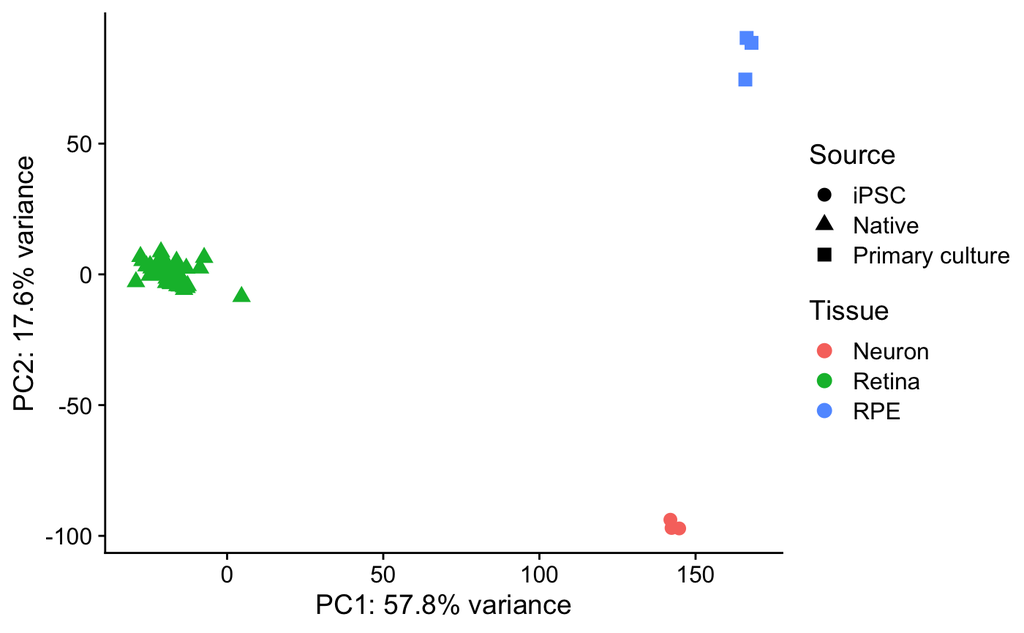

```r
vst <- varianceStabilizingTransformation(DESeq2Table)
library(matrixStats)
ntop = 1000
Pvars <- rowVars(assay(vst))
select <- order(Pvars, decreasing = TRUE)[seq_len(min(ntop,
                                                      length(Pvars)))]
PCA <- prcomp(t(assay(vst)[select, ]), scale = F)
percentVar <- round(100*PCA$sdev^2/sum(PCA$sdev^2),1)
dataGG = data.frame(PC1 = PCA$x[,1], PC2 = PCA$x[,2],
                    PC3 = PCA$x[,3], PC4 = PCA$x[,4],
                    Tissue = colData(vst)$Tissue,
                    Source=colData(vst)$Source)
ggplot(dataGG, aes(PC1, PC2, color=Tissue, shape=Source)) +
  geom_point(size=3) +
  xlab(paste0("PC1: ",percentVar[1],"% variance")) +
  ylab(paste0("PC2: ",percentVar[2],"% variance")) +
  cowplot::theme_cowplot()
```

# 8. Conclusions

1. We show how to pull the EiaD metadata and search it for certain samples
2. We show how to pull raw count information into a matrix from both recount3 and our locally processed EiaD datasets
3. We show how to cut down those count matrices to match the samples in EiaD
4. We do a very brief analysis of the two samples in DESeq2
5. We show now to pull in outside data to do a diff test